# Análise climática do estado de Sergipe

Laboratório de Estatística - Ivan Robert Enriquez Guzman

Elias Ribeiro Rosa Junior e Ornella Scardua Ferreira

Neste trabalho, uma análise de Séries Temporais será feita para avaliar a temperatura do estado de Sergipe com base em covariáveis tais quais: elevação atmosférica, precipitação, radiação, umidade, pressão atmosfésrica e velocidade do vento. A base de dados em análise contém 159.672 observações coletadas da estação Alagoas, em Sergipe, no período de 2000 a 2021.

### Análise descritiva

Inicialmente, construímos uma tabela em que podem ser vistas as principais medidas-resumo e os histogramas das covariáveis, além de gráficos de *boxplot* que reforçam visualmente as informações contidas nessa tabela. A princípio, por meio das medidas e dos *boxplots*, podemos observar que as covariáveis elevação atmosférica, precipitação e radiação estão concentradas em um único intervalo de valores e que os dados associados às covariáveis umidade, pressão atmosférica, velocidade do vento e temperatura parecem estar dispersos em relação à média de maneira razoável. Já os histogramas sugerem distribuições assimétricas em todas covariáveis, embora pressão atmosférica e temperatura apontem para uma leve simetria em suas distribuições.

Tabela 1: Medidas resumo das covariáveis.

Unique (#)

Missing (%)

Mean

SD

Min

Median

Max

height

2

0

4.6

0.3

3.7

4.7

4.7

[figure not shown]

prcp

136

14

0.1

1.0

0.0

0.0

75.4

[figure not shown]

radiacao

5747

50

1903.1

4786.5

0.0

1096.5

47153.0

[figure not shown]

umidade

95

17

71.8

11.2

7.0

72.0

100.0

[figure not shown]

press_atm

21

9

1013.9

2.7

1004.0

1014.0

1023.0

[figure not shown]

vento_velo

92

16

2.9

1.6

0.0

2.9

10.8

[figure not shown]

temp

203

9

26.7

2.1

18.7

26.6

39.4

[figure not shown]

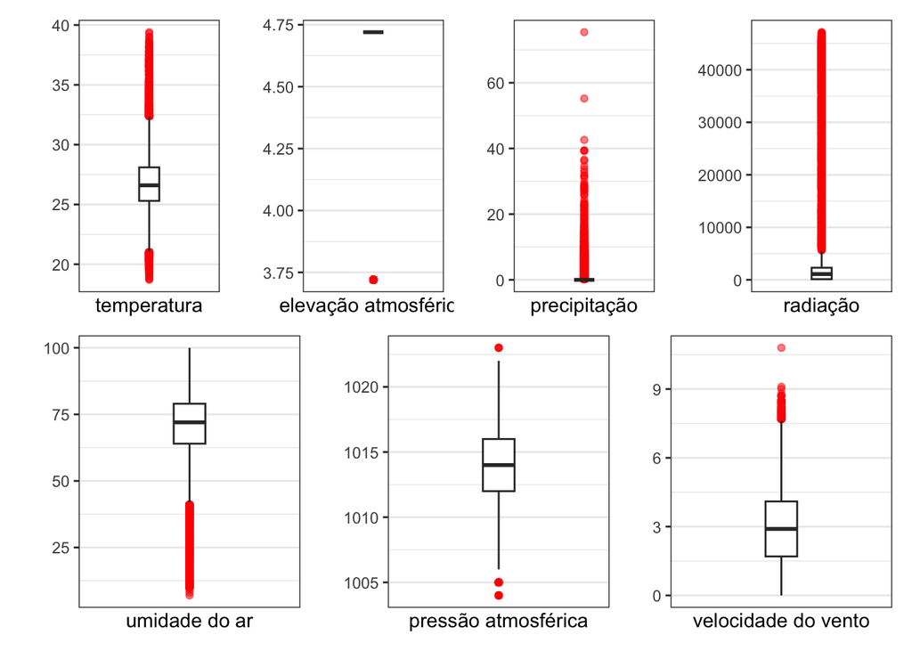

Figura 1: Boxplots das variáveis.

Conferir a correlação entre as covariáveis também é um importante processo na etapa futura de modelagem. Em modelos de Séries Temporais, uma alta correlação entre as variáveis preditoras pode prejudicar seu funcionamento ou mesmo inviabilizá-los. Por isso, com o correlograma abaixo facilmente detectamos os níveis de relação que as covariáveis têm umas com as outras.

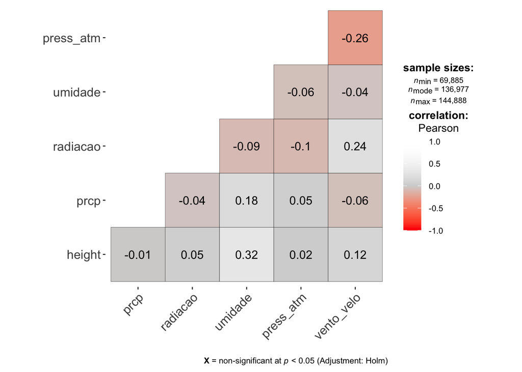

Figura 2: Correlograma das variáveis.

De outra forma, também é interessante entender a relação direta entre cada covariável e a variável resposta, investigando se ela é ou não linear. À vista disso, construímos gráficos de dispersão em que são possíveis fazer suposições a respeito disso. Pela Figura 3 é de notar que a umidade é o fator que parece estar mais linearmente associada à temperatura, no sentido de que quanto maior a umidade, menor será a temperatura.

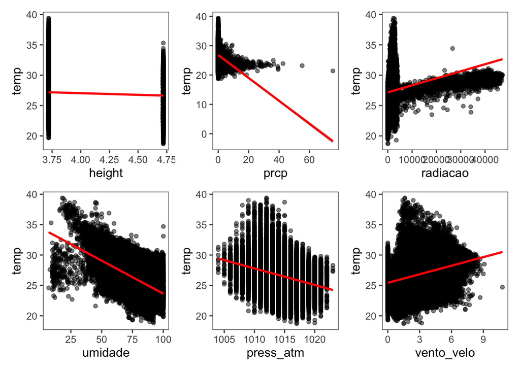

Figura 3: Gráficos de dispersão entre as covariáveis e temperatura.

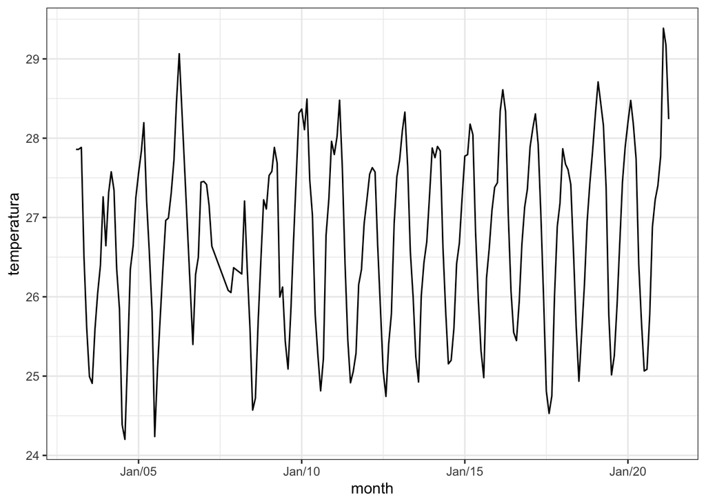

Figura 4: Temperatura média ao longos dos anos, por mês.